# RBIF111 Homework 8

Rita Pecuch

2024-12-02

## Question 1

Objective: Run logistic regression analysis on gene expression levels and the categorical annotation in the selected data set. Identify the gene with the most significant effect on patient gender by this approach. In other words, you will need to loop through all records in your selected data set and perform a logistic regression on each record using the categorical annotation as the outcome. Then, sort the results by p-value and show the top 5 most significant genes. Make a plot of the p-values that were returned. Next, perform multiple hypothesis testing using leave-n-out re-sampling. For each gene in the data set, leave one randomly selected sample out. Then save the p-value of the logistic regression analysis that was performed. Repeat this 100 times. Then calculate the average and variance across the re-sampled p-values. Describe and interpret the results. Finally, repeat this process with both the normalized and non-normalized samples. If your data set contains gene expression levels that are relatively consistent between all samples, you can artificially inflate or decrease the expression level by adding or subtracting the expression levels by a correction factor.

Chosen dataset: Differential diagnosis between uterine leiomyoma and leiomyosarcoma (10 leiomyoma samples, 10 leiomyosarcoma samples)

Experiment type: Expression profiling by high throughput sequencing

GSEXXX number: GSE222045

gplXXX number: GPL24676

Code to download expression data:

```r
# Define download function for RNAseq dataset
GEODataDownload <- function(DS, gpl, gsm){
  library(DESeq2)
  library(limma)
  library(data.table)

  ACC <- paste("acc=", DS, sep = "")
  file <- paste("file=", DS, "_raw_counts_GRCh38.p13_NCBI.tsv.gz", sep = "")
  comp <- gsub(" ", "", gsm)
  comp <- gsub(",", "", comp)
  gsms <- paste0(comp)
  #### Set up DEG names ####
  urld <- "https://www.ncbi.nlm.nih.gov/geo/download/?format=file&type=rnaseq_counts"
  path <- paste(urld, ACC, file, sep="&");
  tbl <- as.matrix(data.table::fread(path, header=T, colClasses="integer"), rownames="GeneID")

  apath <- paste(urld, "type=rnaseq_counts", "file=Human.GRCh38.p13.annot.tsv.gz", sep="&")
  annot <- data.table::fread(apath, header=T, quote="", stringsAsFactors=F, data.table=F)
  rownames(annot) <- annot$GeneID
  # filter out excluded samples (marked as "X")
  sml <- strsplit(gsms, split="")[[1]]
  sel <- which(sml != "X")
  tbl <- tbl[ ,sel]

  tT <- merge(as.data.frame(tbl), annot, by=0, sort=F)
  #### Adjust column names ####
  setnames(tT, c("GeneID", "Symbol", "Description"), c("ENTREZID", "SYMBOL", "GENENAME"))

  return(tT)
}

# Execute download function
RNA_Seq_Data <- GEODataDownload(DS = "GSE222045", gpl = "GPL24676", gsm = "0000000000000000000XXXXX0XXXXXXXX")
```

Code to load sample metadata:

```r
library(dplyr)

# Read sample metadata
metadata_path <- "/Users/ritapecuch/Desktop/Brandeis/RBIF111/Week 8/differential_study_metadata.csv"
metadata <- read.table(metadata_path, sep=",", header=TRUE) %>%
  select(Sample.Name, disease_state)
```

The below code block filters the RNA sequencing experiment metadata to only include samples that were included in the download of the expression data. The disease diagnosis of each sample is assigned a binary classifier to be compatible with logistic regression. Then, a logistic regression model is fit for each gene between the diagnosis and gene expression level. The ANOVA test is performed to extract the p-value representing the significance of each fit and all p-values are added to the expression data. Next, the expression data is sorted by ascending p-value and NA p-values are filtered out. A table with the top 5 most significant genes is printed below, and they all have a p-value < 1.4e-7, representing a highly statistically significant relationship between diagnosis and the expression of these genes.

```r
library(dplyr)

# Match diagnoses to samples and assign binary levels
diag_df <- metadata[metadata$Sample.Name %in% names(RNA_Seq_Data), ]
diag_df$disease_binary <- ifelse(diag_df$disease_state == "Leiomyoma", 0, 1)
diags <- diag_df$disease_binary
names(diags) <- diag_df$Sample.Name

# Loop through genes
for (row in c(1:nrow(RNA_Seq_Data))){
  # Get gene exp levels in same order as corresponding diagnoses
  exp_levels <- unlist(RNA_Seq_Data[row, names(diags)])

  # Fit logistic regression model
  glm <- glm(diags ~ exp_levels, family = "binomial")
  p_value <- anova(glm)[2, "Pr(>Chi)"]

  # Save p-value
  RNA_Seq_Data[row, "P_Value"] <- p_value
}

# Sort results by p-value and display top 5 most significant genes
sorted_exp_data <- RNA_Seq_Data[!is.na(RNA_Seq_Data$P_Value), ]
sorted_exp_data <- sorted_exp_data[order(sorted_exp_data$ENTREZID),]
sorted_exp_data <- sorted_exp_data[order(sorted_exp_data$P_Value),]
display_exp_data <- sorted_exp_data[1:5, c("SYMBOL", "P_Value")]
print(display_exp_data)
```

```
##       SYMBOL      P_Value
## 31687   HROB 1.397796e-07
## 29204 PKMYT1 1.397796e-07
## 25169  CRYL1 1.397796e-07
## 34208  WDR62 1.397796e-07
## 3127  ATP2B4 1.397796e-07
```

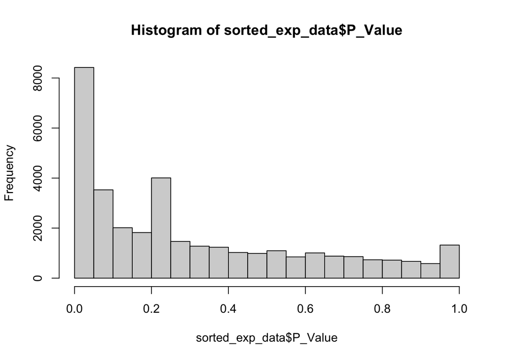

```r
# Plot distribution of p-values
hist(sorted_exp_data$P_Value)
```

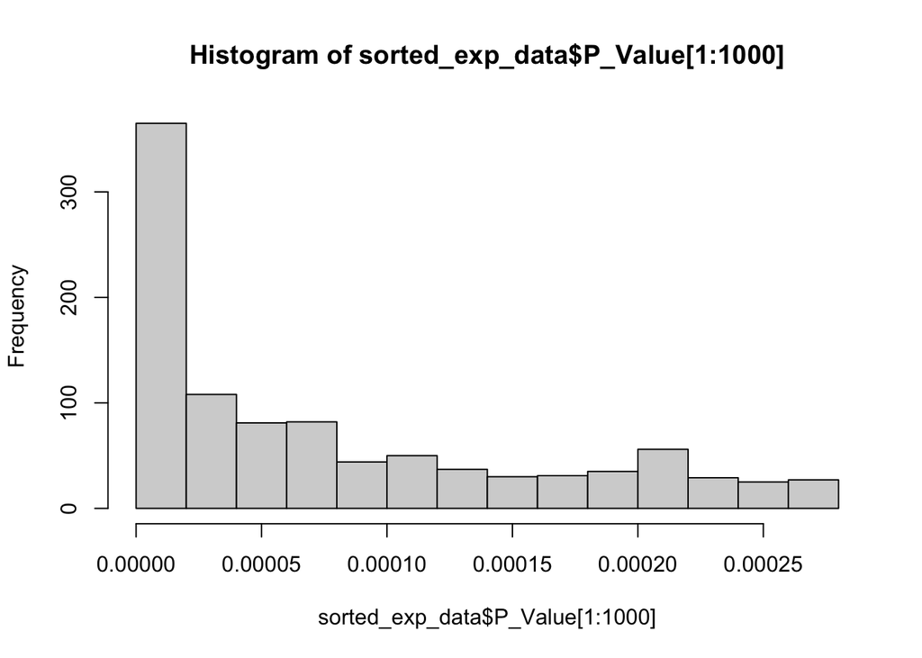

```r
# Plot distribution of p-values for top 1000 most significant genes
hist(sorted_exp_data$P_Value[1:1000])
```

The below code block performs multiple hypothesis testing using 100 rounds of leave-n-out resampling for each of the 1000 most significant genes. For each round of resampling, one sample is randomly chosen to leave out. Then, a logistic regression model is fit between the diagnosis and gene expression level for all samples except for the sample that has been left out. The ANOVA test is performed to extract the p-value representing the significance of each fit. All p-values for the gene (from each round of resampling) are saved to a vector. The average and variance across the re-sampled p-values are calculated for each gene and saved to the expression data. Next, the expression data is sorted by ascending average p-value and NA average p-values are filtered out. A table with the top 5 most significant genes from this simulation is printed below. For the most part, the top 5 most significant genes are the same as the top 5 most significant genes seen in the previous simulation, but the average p-values are slightly higher than the original p-values. An extremely small variance in p-values is seen for each of the genes.

```r
# Loop through 1000 most significant genes
for (row in c(1:1000)){
  # Keep track of p-values from each round
  p_values_adj <- c()

  # 100 rounds of leave-n-out re-sampling
  for (i in c(1:100)){
    # Randomly select sample to leave out
    index <- sample(c(1:length(diags)), 1)
    diags_adj <- diags[-index]
    exp_levels_adj <- unlist(sorted_exp_data[row, names(diags_adj)])

    # Fit logistic regression model
    glm <- glm(diags_adj ~ exp_levels_adj, family = "binomial")
    p_value_adj <- anova(glm)[2, "Pr(>Chi)"]

    # Save p-value by adding to vector of all p-values for gene
    p_values_adj <- c(p_values_adj, p_value_adj)
  }

  # Calculate average and variance across re-sampled p-values
  p_value_avg <- mean(p_values_adj, na.rm=T)
  p_value_var <- var(p_values_adj, na.rm=T)
  # Save statistics
  sorted_exp_data[row, "P_Value_Avg"] <- p_value_avg
  sorted_exp_data[row, "P_Value_Var"] <- p_value_var
}

# Sort results by p-value and display top 5 most significant genes
resorted_exp_data <- sorted_exp_data[!is.na(sorted_exp_data$P_Value_Avg), ]
resorted_exp_data <- resorted_exp_data[order(resorted_exp_data$P_Value_Avg),]
redisplay_exp_data <- resorted_exp_data[1:5, c("SYMBOL", "P_Value", "P_Value_Avg", "P_Value_Var")]
print(redisplay_exp_data)
```

```
##       SYMBOL      P_Value  P_Value_Avg  P_Value_Var
## 31687   HROB 1.397796e-07 2.942724e-07 5.223341e-34
## 29204 PKMYT1 1.397796e-07 2.942724e-07 1.926713e-34
## 25169  CRYL1 1.397796e-07 2.942724e-07 2.109713e-34
## 3127  ATP2B4 1.397796e-07 2.942724e-07 1.622753e-33
## 34208  WDR62 1.397796e-07 2.942724e-07 4.302404e-34
```

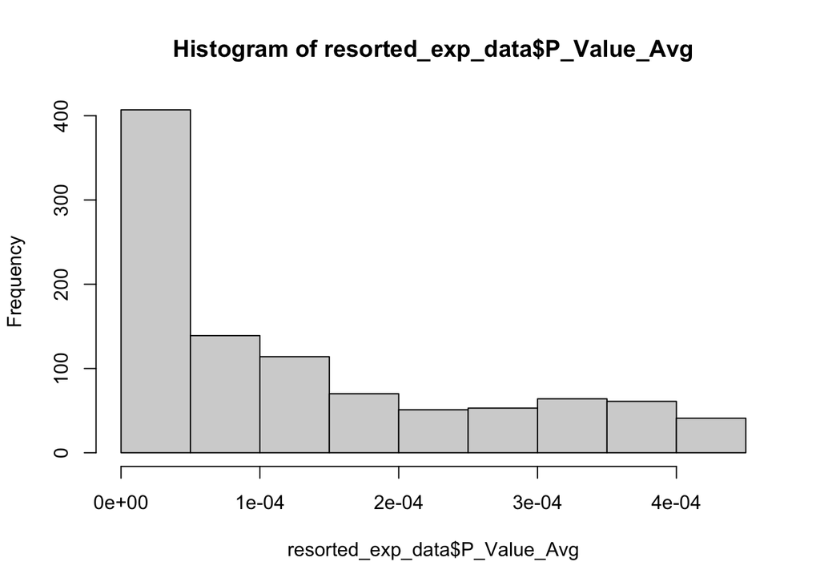

```r
# Plot distribution of p-value averages
hist(resorted_exp_data$P_Value_Avg)
```

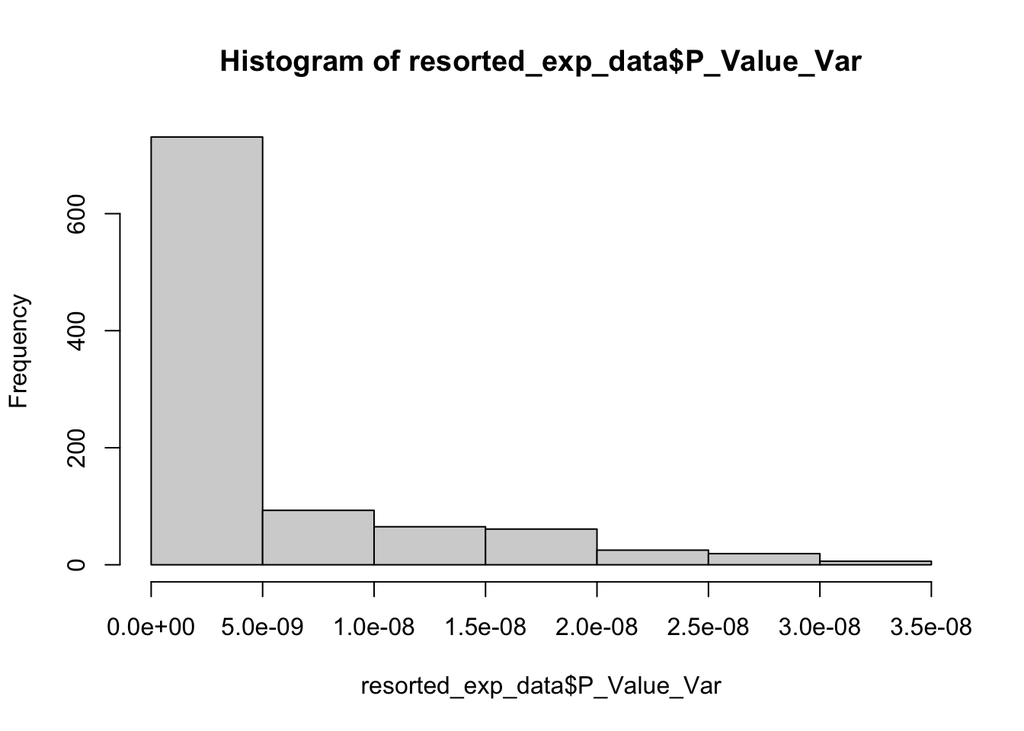

```r
# Plot distribution of p-value variances
hist(resorted_exp_data$P_Value_Var)
```

Code to download normalized expression data:

```r
GEODataDownload_norm <- function(DS, gpl, gsm, batch_correction=FALSE){
  library(DESeq2)
  library(limma)
  library(data.table)

  # Set up query parameters and path for expression data
  ACC <- paste("acc=", DS, sep = "")
  file <- paste("file=", DS, "_raw_counts_GRCh38.p13_NCBI.tsv.gz", sep = "")
  urld <- "https://www.ncbi.nlm.nih.gov/geo/download/?format=file&type=rnaseq_counts"
  path <- paste(urld, ACC, file, sep="&")
  # Get expression data
  tbl <- as.matrix(data.table::fread(path, header=T, colClasses="integer"), rownames="GeneID")
  exraw <- tbl
  # Get annotation data
  apath <- paste(urld, "type=rnaseq_counts", "file=Human.GRCh38.p13.annot.tsv.gz", sep="&")
  annot <- data.table::fread(apath, header=T, quote="", stringsAsFactors=F, data.table=F)
  rownames(annot) <- annot$GeneID
  # Subset to only needed tables
  comp <- gsub(" ", "", gsm)
  comp <- gsub(",", "", comp)
  gsms <- paste0(comp)
  sml <- strsplit(gsms, split="")[[1]]
  sel <- which(sml != "X")
  sml <- sml[sel]
  tbl <- tbl[ ,sel]
  # Split into groups
  gs <- factor(sml)
  groups <- make.names(c("Ctrl", "Tx"))
  levels(gs) <- groups
  sample_info <- data.frame(Group = gs, row.names = colnames(tbl))
  keep <- rowSums( tbl >= 10 ) >= min(table(gs))
  tbl <- tbl[keep, ]
  if (length(unique(gs)) == 1){
    ds <- DESeqDataSetFromMatrix(countData=tbl, colData=sample_info, design= ~1)
  } else{
    ds <- DESeqDataSetFromMatrix(countData=tbl, colData=sample_info, design= ~Group)
  }
  # Obtain normalized count values
  if (batch_correction){
    est <- estimateSizeFactors(ds)
    NormCounts <- counts(est, normalized = TRUE)
  } else{
    NormCounts <- tbl
  }

  # Merge expression and annotation data
  tT <- merge(as.data.frame(NormCounts), annot, by=0, sort=F)
  # Adjust column names
  setnames(tT, c("GeneID", "Symbol", "Description"), c("ENTREZID", "SYMBOL", "GENENAME"))
  return(tT)
}

# Execute download function
RNA_Seq_Data_norm <- GEODataDownload_norm(DS = "GSE222045", gpl = "GPL24676", gsm = "0000000000000000000XXXXX0XXXXXXXX", batch_correction=TRUE)
```

The below code block repeats the first simulation using normalized expression data. A logistic regression model is fit for each gene between the diagnosis and normalized gene expression level. The ANOVA test is performed to extract the p-value representing the significance of each fit and all p-values are added to the normalized expression data. Next, the normalized expression data is sorted by ascending p-value and NA p-values are filtered out. A table with the top 5 most significant genes is printed below, and they all have a p-value < 1.4e-7, representing a highly statistically significant relationship between diagnosis and the expression of these genes. Compared to the results from the non-normalized expression data, a few of the genes that were identified as top 5 most significant before normalization are no longer present as top 5 most significant after normalization.

```r
# Loop through genes
for (row in c(1:nrow(RNA_Seq_Data_norm))){
  # Get gene exp levels in same order as corresponding diagnoses
  exp_levels <- unlist(RNA_Seq_Data_norm[row, names(diags)])

  # Fit logistic regression model
  glm <- glm(diags ~ exp_levels, family = "binomial")
  p_value <- anova(glm)[2, "Pr(>Chi)"]

  # Save p-value
  RNA_Seq_Data_norm[row, "P_Value"] <- p_value
}

# Sort results by p-value and display top 5 most significant genes
sorted_exp_data_norm <- RNA_Seq_Data_norm[!is.na(RNA_Seq_Data_norm$P_Value), ]
sorted_exp_data_norm <- sorted_exp_data_norm[order(sorted_exp_data_norm$P_Value),]
display_exp_data_norm <- sorted_exp_data_norm[1:5, c("SYMBOL", "P_Value")]
print(display_exp_data_norm)
```

```
##        SYMBOL      P_Value
## 31687    HROB 1.397796e-07
## 12751 ZSCAN26 1.397796e-07
## 20377  ZNF503 1.397796e-07
## 25169   CRYL1 1.397796e-07
## 25492     ESD 1.397796e-07
```

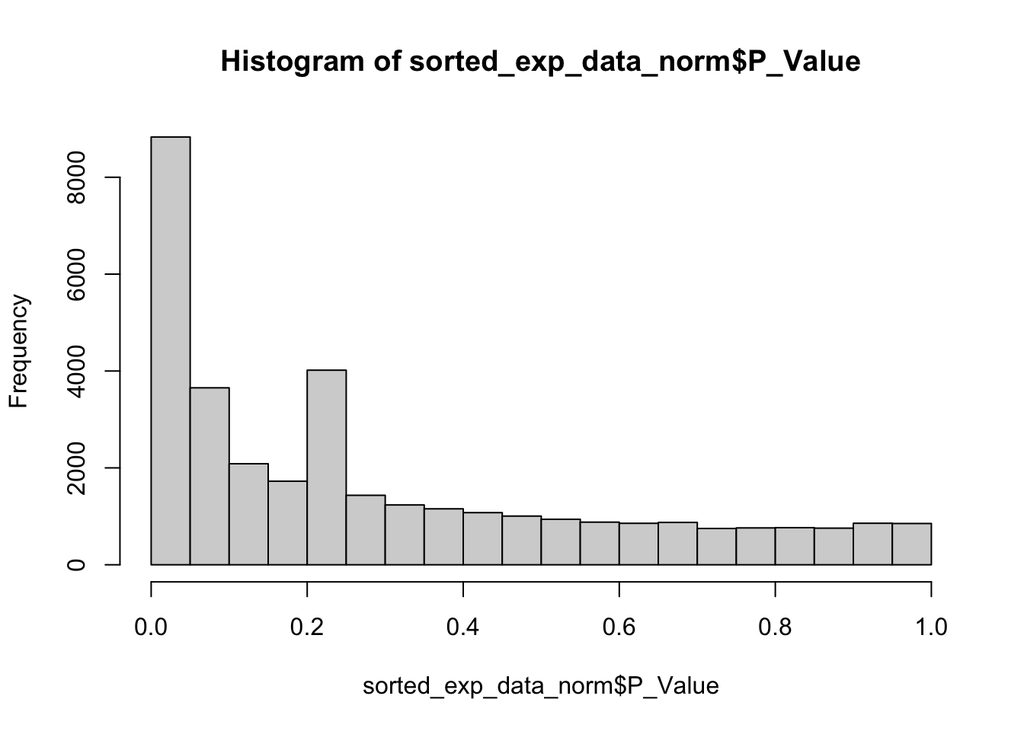

```r
# Plot distribution of p-values
hist(sorted_exp_data_norm$P_Value)
```

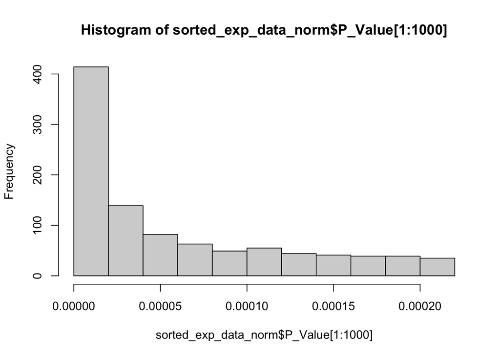

```r
# Plot distribution of p-values for top 1000 most significant genes
hist(sorted_exp_data_norm$P_Value[1:1000])
```

## Question 2

Objective: Time to event survival analysis.

The below code block generates a survival object for the dialysis survival dataset. Patients that have died at the time of data collection are represented with event = 1, and patients that are still alive at the time of data collection are represented with event = 0. This binary classification works perfectly with the Surv() function to create the survival object. Next, a model is fitted between the survival object and disease type and plotted below. Visual inspection of the plot shows that survival time does not appear to be significantly different between the “renal”, “hypertension”, and “other” disease groups. The survival time appears to be slightly longer in the “congen” disease group due to higher probabilities of a patient being alive at each of the time points visualized on the plot. The survival time appears to be slightly shorter in the “diabetes” disease group due to lower probabilities of the patient being alive at each of the time points visualized on the plot. Finally, the Cox Proportional Hazards model is used to assess the significance between survival time and disease type. The results show a very statistically significant difference (p = 5.34e-6) between the survival times between “congen” and “diabetes” patients, which confirms the prediction made by visual inspection of the plot. Less extreme statistically significant differences (p between 0.006 and 0.015) are also observed between the survival times of the “congen” groups and the remaining disease groups.

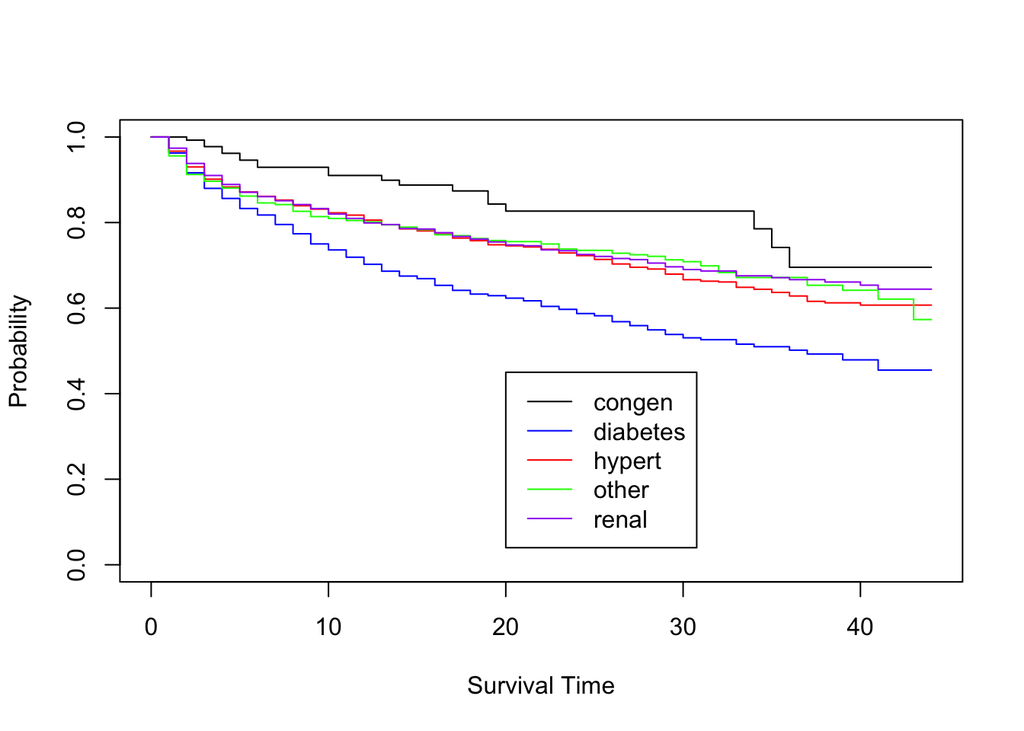

```r
library(survival)

# Read data
data_path <- "/Users/ritapecuch/Desktop/Brandeis/RBIF111/Week 8/Dialysis.csv"
dialysis_data <- read.table(data_path, sep=",", header=TRUE)

# Generate survival object
surv_obj <- Surv(dialysis_data$time, dialysis_data$event)
# Fit model between survival and disease
model <- survfit(surv_obj~dialysis_data$fac_disease)

# Plot model
plot_colors <- c('black', "blue", "red", "green", "purple")
plot(model,
 col=plot_colors,
 xlab="Survival Time",
 ylab="Probability"
 )
# Add legend for disease type stratification
disease_types <- sort(unique(dialysis_data$fac_disease))
legend(20,0.45,legend=disease_types,lwd=1,col=plot_colors)
```

```r
# Assess significance of relationship between disease type and survival
coxph(surv_obj~dialysis_data$fac_disease)
```

```
## Call:
## coxph(formula = surv_obj ~ dialysis_data$fac_disease)
##
##                                     coef exp(coef) se(coef)     z        p
## dialysis_data$fac_diseasediabetes 1.0428    2.8371   0.2291 4.551 5.34e-06
## dialysis_data$fac_diseasehypert   0.6199    1.8588   0.2270 2.730  0.00633
## dialysis_data$fac_diseaseother    0.6110    1.8423   0.2330 2.623  0.00872
## dialysis_data$fac_diseaserenal    0.5608    1.7521   0.2310 2.428  0.01518
##
## Likelihood ratio test=66.69  on 4 df, p=1.134e-13
## n= 6805, number of events= 1603
```